# 201533892_홍기현

### 201533892-홍기현-중간고사

**사용 패키지 불러오기**

```python
import pandas as pd
import matplotlib as mpl
import matplotlib.pylab as plt
import seaborn as sns
import numpy as np
```

**사용할 data set을 불러오고 연속형 데이터와 범주형 데이터 확인**

```python
file_path = 'C:/data/빅클중간고사_데이터.csv'
df = pd.read_csv(file_path, engine='python')

print(df.info())
df.head()
```

```
<class 'pandas.core.frame.DataFrame'>
RangeIndex: 409 entries, 0 to 408
Data columns (total 13 columns):
 #   Column  Non-Null Count  Dtype
---  ------  --------------  -----
 0   가격      409 non-null    int64
 1   회사명     409 non-null    object
 2   년식      409 non-null    int64
 3   종류      409 non-null    object
 4   연비      401 non-null    float64
 5   마력      383 non-null    float64
 6   토크      394 non-null    float64
 7   연료      409 non-null    object
 8   LPG     409 non-null    int64
 9   하이브리드   409 non-null    int64
 10  배기량     390 non-null    float64
 11  중량      399 non-null    float64
 12  변속기     409 non-null    object
dtypes: float64(5), int64(4), object(4)
memory usage: 41.7+ KB
None
```

|  | 가격 | 회사명 | 년식 | 종류 | 연비 | 마력 | 토크 | 연료 | LPG | 하이브리드 | 배기량 | 중량 | 변속기 |
| --- | --- | --- | --- | --- | --- | --- | --- | --- | --- | --- | --- | --- | --- |
| 0 | 8620 | 기아 | 2015 | 대형 | 7.6 | 425.0 | 52.0 | 가솔린 | 0 | 0 | 5038.0 | 2105.0 | 자동 |
| 1 | 11150 | 현대 | 2015 | 대형 | 8.1 | 416.0 | 52.0 | 가솔린 | 0 | 0 | 5038.0 | 2065.0 | 자동 |
| 2 | 14570 | 현대 | 2015 | 대형 | 7.4 | 416.0 | 52.0 | 가솔린 | 0 | 0 | 5038.0 | 2145.0 | 자동 |
| 3 | 10687 | 쌍용 | 2015 | 대형 | 7.5 | 306.0 | 45.0 | 가솔린 | 0 | 0 | 4966.0 | 2070.0 | 자동 |
| 4 | 9324 | 쌍용 | 2015 | 대형 | 7.6 | 306.0 | 45.0 | 가솔린 | 0 | 0 | 4966.0 | 1960.0 | 자동 |

### 데이터 클린징

데이터 분석을 위한 data set에서 분석가의 모든 기대를 충족하는 데이터를 없다. 따라서 분석가가 데이터 분석을 위해서 **데이터 클린징** 과정은 매우 중요하다.  
데이터 클린징으로 크게 3가지 데이터를 제거/대체 한다.

- 결측 데이터
- 이상 데이터
- 중복 데이터

본 데이터 분석에서 데이터 클린징은 이상치부터 처리하기로 한다.  
**만약 결측치를 먼저 처리한다면, 결측값을 평균값이나 중위수로 대체 시 많이 다른 이상치로 인한 잘못된 값으로 대체될 가능성도 있다고 판단했기 때문이다.**

**이상치 제거**

```python
df.describe()
```

|  | 가격 | 년식 | 연비 | 마력 | 토크 | LPG | 하이브리드 | 배기량 | 중량 |
| --- | --- | --- | --- | --- | --- | --- | --- | --- | --- |
| count | 409.000000 | 409.000000 | 401.000000 | 383.000000 | 394.000000 | 409.000000 | 409.000000 | 390.000000 | 399.000000 |
| mean | 2161.750611 | 2013.924205 | 75.100998 | 146.955614 | 24.437817 | 0.085575 | 0.017115 | 1859.671795 | 1447.220551 |
| std | 1501.027709 | 1.400849 | 554.094633 | 60.424377 | 12.428520 | 0.280077 | 0.129858 | 729.375872 | 411.709473 |
| min | 714.000000 | 2010.000000 | 6.300000 | 41.000000 | 6.700000 | 0.000000 | 0.000000 | 796.000000 | 735.000000 |
| 25% | 1261.000000 | 2013.000000 | 10.400000 | 108.000000 | 13.900000 | 0.000000 | 0.000000 | 1396.000000 | 1056.000000 |
| 50% | 1845.000000 | 2015.000000 | 13.000000 | 140.000000 | 21.000000 | 0.000000 | 0.000000 | 1975.500000 | 1465.000000 |
| 75% | 2576.000000 | 2015.000000 | 15.000000 | 177.500000 | 36.700000 | 0.000000 | 0.000000 | 2199.000000 | 1810.000000 |
| max | 14570.000000 | 2015.000000 | 5000.000000 | 425.000000 | 56.000000 | 1.000000 | 1.000000 | 5038.000000 | 2383.000000 |

describe() 메소드를 사용하여 확인한 결과는 다음과 같다

해당 이상치를 제거하는 것을 우선으로 한다  
이상치 제거는 boxplot을 이용하여 시각화한 후에, 제거하게 된다.

```python
sns.set_palette('pastel')
plt.rc('font', family='Malgun Gothic')
```

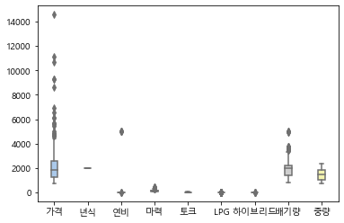

```python
sns.boxplot(data=df ,width=0.2)
```

boxplot()을 통하여 시각화를 통하여 분석한 결과, 다음의 이상치를 제거하도록한다.

```python
df = df[(df['연비'] <= 1000)]
df = df[(df['배기량'] <= 4500)]
```

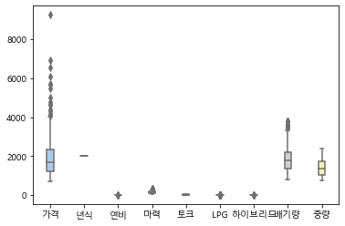

```python
sns.boxplot(data=df ,width=0.2)
```

boxplot()을 통하여 이상치를 제거한 것을 본 결과이다.

```python
df.describe()
```

|  | 가격 | 년식 | 연비 | 마력 | 토크 | LPG | 하이브리드 | 배기량 | 중량 |
| --- | --- | --- | --- | --- | --- | --- | --- | --- | --- |
| count | 372.000000 | 372.000000 | 372.000000 | 349.000000 | 359.000000 | 372.000000 | 372.000000 | 372.000000 | 363.000000 |
| mean | 1973.500000 | 2013.873656 | 13.067742 | 141.163324 | 23.561281 | 0.091398 | 0.018817 | 1813.314516 | 1414.922865 |
| std | 1084.037296 | 1.426607 | 3.155465 | 54.495167 | 12.199656 | 0.288562 | 0.136062 | 648.044993 | 406.715132 |
| min | 714.000000 | 2010.000000 | 6.300000 | 41.000000 | 6.700000 | 0.000000 | 0.000000 | 796.000000 | 735.000000 |
| 25% | 1214.500000 | 2013.000000 | 10.775000 | 108.000000 | 13.900000 | 0.000000 | 0.000000 | 1368.000000 | 1050.000000 |
| 50% | 1665.000000 | 2015.000000 | 13.200000 | 136.000000 | 20.400000 | 0.000000 | 0.000000 | 1796.000000 | 1365.000000 |
| 75% | 2346.500000 | 2015.000000 | 15.000000 | 175.000000 | 35.000000 | 0.000000 | 0.000000 | 2199.000000 | 1727.500000 |
| max | 9254.000000 | 2015.000000 | 22.000000 | 334.000000 | 56.000000 | 1.000000 | 1.000000 | 3778.000000 | 2383.000000 |

describe() 메소드를 확인한 결과 이상치가 제거 되었음을 볼 수 있다  
그리고, 범주형의 데이터의 이상치를 제거를 위해, 값을 확인해야 한다

**범주형의 이상치를 제거하기 위해 crosstab()을 이용하여 어떠한 group이 있는지 한눈에 파악하기로 한다.**  
범주형 데이터에는 **회사명, 년식, 종류, 연료, LPG, 하이브리드, 변속기**가 있다.

```python
pd.crosstab([df['회사명'], df['년식'], df['종류']], [df['연료'], df['LPG'], df['하이브리드'], df['변속기']])
```

| 회사명 | 년식 | 연료 LPG 하이브리드 변속기 종류 | LPG 0 수동 | LPG 0 자동 | LPG 1 0 수동 | LPG 1 0 자동 | LPG 1 자동 | 가솔린 0 수동 | 가솔린 0 자동 | 가솔린 0 1 자동 | 디젤 0 수동 | 디젤 0 자동 | 디젤 1 0 수동 | 디젤 1 0 자동 |
| --- | --- | --- | --- | --- | --- | --- | --- | --- | --- | --- | --- | --- | --- | --- |
| 기아 | 2010 | 경형 | 0 | 0 | 0 | 0 | 0 | 2 | 2 | 0 | 0 | 0 | 0 | 0 |
|  |  | 소형 | 0 | 0 | 0 | 0 | 0 | 2 | 2 | 0 | 0 | 0 | 0 | 0 |
|  | 2011 | 경형 | 0 | 0 | 0 | 0 | 0 | 2 | 2 | 0 | 0 | 0 | 0 | 0 |
|  | 2012 | 경형 | 0 | 0 | 0 | 0 | 0 | 2 | 3 | 0 | 0 | 0 | 0 | 0 |
|  |  | 소형 | 0 | 0 | 0 | 0 | 0 | 2 | 2 | 0 | 0 | 0 | 0 | 0 |
| ... | ... | ... | ... | ... | ... | ... | ... | ... | ... | ... | ... | ... | ... | ... |
| 현대 | 2014 | 소형 | 0 | 0 | 0 | 0 | 0 | 1 | 3 | 0 | 0 | 0 | 0 | 0 |
|  | 2015 | 대형 | 1 | 1 | 1 | 1 | 0 | 0 | 6 | 1 | 6 | 7 | 1 | 1 |
|  |  | 소형 | 0 | 0 | 0 | 0 | 0 | 1 | 3 | 0 | 2 | 2 | 0 | 0 |
|  |  | 준중형 | 0 | 0 | 0 | 0 | 0 | 4 | 4 | 0 | 5 | 7 | 0 | 0 |
|  |  | 중형 | 0 | 0 | 0 | 0 | 0 | 0 | 7 | 1 | 2 | 8 | 0 | 0 |

61 rows × 12 columns

crosstab()으로 범주형의 이상치를 한번에 확인해본 결과, 범주형에는 이상이 없는 것으로 보인다.

**결측치 제거**

결측치를 제거하기 위해 count()메소드로 전체 데이터의 수와, isnull() 메소드로 결측 데이터의 수를 판단한다.

```python
print(df.count())
print()
print(df.isnull().sum())
```

```
가격       372
회사명      372
년식       372
종류       372
연비       372
마력       349
토크       359
연료       372
LPG      372
하이브리드    372
배기량      372
중량       363
변속기      372
dtype: int64

가격        0
회사명       0
년식        0
종류        0
연비        0
마력       23
토크       13
연료        0
LPG       0
하이브리드     0
배기량       0
중량        9
변속기       0
dtype: int64
```

count() 메소드로 전체적인 데이터의 갯수를 파악한 후, isnull().sum() 매소드로 결측값이 갯수를 파악한다. 이를 통하여 전체 데이터에서 얼만큼의 결측 데이터가 발생했는지 파악하며, 분석 결과 다음과 같은 방법으로 결측 데이터를 제거하도록 한다.

- 마력은 평균으로 대체한다
- 토크와 중량은 데이터가 비교적으로 적으므로, 데이터 분석에 영향이 적을 것이라 판단하여 제거하도록 한다.

  해당 조건대로 처리한 결과는 다음과 같다.

```python
df.마력 = df.마력.fillna(df.mean()['마력'])
```

```python
df = df.dropna(axis=0)
print(df.isnull().sum())
```

```
가격       0
회사명      0
년식       0
종류       0
연비       0
마력       0
토크       0
연료       0
LPG      0
하이브리드    0
배기량      0
중량       0
변속기      0
dtype: int64
```

**데이터 분석 과정에서 범주형 변수와 연속형 변수의 구분을 명확하기 하기 위해 범주형 변수는 object type으로, 연속형 변수는 int, float type으로 통일한다.**

```python
df.info()
```

```
<class 'pandas.core.frame.DataFrame'>
Int64Index: 350 entries, 5 to 408
Data columns (total 13 columns):
 #   Column  Non-Null Count  Dtype
---  ------  --------------  -----
 0   가격      350 non-null    int64
 1   회사명     350 non-null    object
 2   년식      350 non-null    int64
 3   종류      350 non-null    object
 4   연비      350 non-null    float64
 5   마력      350 non-null    float64
 6   토크      350 non-null    float64
 7   연료      350 non-null    object
 8   LPG     350 non-null    int64
 9   하이브리드   350 non-null    int64
 10  배기량     350 non-null    float64
 11  중량      350 non-null    float64
 12  변속기     350 non-null    object
dtypes: float64(5), int64(4), object(4)
memory usage: 38.3+ KB
```

```python
df.년식 = df.년식.astype(str)

df.LPG = df.LPG.astype(str)
df.하이브리드 = df.하이브리드.astype(str)

df.info()
```

```
<class 'pandas.core.frame.DataFrame'>
Int64Index: 350 entries, 5 to 408
Data columns (total 13 columns):
 #   Column  Non-Null Count  Dtype
---  ------  --------------  -----
 0   가격      350 non-null    int64
 1   회사명     350 non-null    object
 2   년식      350 non-null    object
 3   종류      350 non-null    object
 4   연비      350 non-null    float64
 5   마력      350 non-null    float64
 6   토크      350 non-null    float64
 7   연료      350 non-null    object
 8   LPG     350 non-null    object
 9   하이브리드   350 non-null    object
 10  배기량     350 non-null    float64
 11  중량      350 non-null    float64
 12  변속기     350 non-null    object
dtypes: float64(5), int64(1), object(7)
memory usage: 38.3+ KB
```

**중복값 제거**

```python
df.duplicated()
df.drop_duplicates()
```

|  | 가격 | 회사명 | 년식 | 종류 | 연비 | 마력 | 토크 | 연료 | LPG | 하이브리드 | 배기량 | 중량 | 변속기 |
| --- | --- | --- | --- | --- | --- | --- | --- | --- | --- | --- | --- | --- | --- |
| 5 | 5680 | 기아 | 2015 | 대형 | 9.3 | 334.0 | 40.3 | 가솔린 | 0 | 0 | 3778.0 | 1940.0 | 자동 |
| 6 | 6910 | 현대 | 2015 | 대형 | 8.9 | 334.0 | 40.3 | 가솔린 | 0 | 0 | 3778.0 | 1915.0 | 자동 |
| 7 | 5463 | 현대 | 2015 | 대형 | 9.0 | 315.0 | 40.5 | 가솔린 | 0 | 0 | 3778.0 | 1930.0 | 자동 |
| 8 | 5710 | 현대 | 2015 | 대형 | 8.5 | 315.0 | 40.5 | 가솔린 | 0 | 0 | 3778.0 | 2000.0 | 자동 |
| 9 | 9254 | 쌍용 | 2015 | 대형 | 8.0 | 250.0 | 35.0 | 가솔린 | 0 | 0 | 3598.0 | 2070.0 | 자동 |
| ... | ... | ... | ... | ... | ... | ... | ... | ... | ... | ... | ... | ... | ... |
| 404 | 741 | 대우 | 2012 | 경형 | 9.8 | 43.0 | 6.7 | LPG | 1 | 0 | 796.0 | 735.0 | 수동 |
| 405 | 958 | 대우 | 2015 | 경형 | 9.2 | 43.0 | 6.7 | LPG | 1 | 0 | 796.0 | 865.0 | 수동 |
| 406 | 964 | 대우 | 2015 | 경형 | 9.0 | 41.0 | 6.7 | LPG | 1 | 0 | 796.0 | 905.0 | 수동 |
| 407 | 904 | 대우 | 2013 | 경형 | 9.9 | 41.0 | 6.7 | LPG | 1 | 0 | 796.0 | 865.0 | 수동 |
| 408 | 910 | 대우 | 2013 | 경형 | 9.6 | 41.0 | 6.7 | LPG | 1 | 0 | 796.0 | 905.0 | 수동 |

348 rows × 13 columns

**사실, 해당 data set의 범주형 데이터의 의미가 불분명하다. 따라서 데이터를 의미가 분명하도록 치환하여 분석이 용이하도록 변환한다**

```python
df.loc[df['LPG'] == "0", 'LPG'] = 'no'
df.loc[df['LPG'] == "1", 'LPG'] = 'yes'

df.loc[df['하이브리드'] == "0", '하이브리드'] = 'no'
df.loc[df['하이브리드'] == "1", '하이브리드'] = 'yes'
```

```python
df
```

|  | 가격 | 회사명 | 년식 | 종류 | 연비 | 마력 | 토크 | 연료 | LPG | 하이브리드 | 배기량 | 중량 | 변속기 |
| --- | --- | --- | --- | --- | --- | --- | --- | --- | --- | --- | --- | --- | --- |
| 5 | 5680 | 기아 | 2015 | 대형 | 9.3 | 334.0 | 40.3 | 가솔린 | no | no | 3778.0 | 1940.0 | 자동 |
| 6 | 6910 | 현대 | 2015 | 대형 | 8.9 | 334.0 | 40.3 | 가솔린 | no | no | 3778.0 | 1915.0 | 자동 |
| 7 | 5463 | 현대 | 2015 | 대형 | 9.0 | 315.0 | 40.5 | 가솔린 | no | no | 3778.0 | 1930.0 | 자동 |
| 8 | 5710 | 현대 | 2015 | 대형 | 8.5 | 315.0 | 40.5 | 가솔린 | no | no | 3778.0 | 2000.0 | 자동 |
| 9 | 9254 | 쌍용 | 2015 | 대형 | 8.0 | 250.0 | 35.0 | 가솔린 | no | no | 3598.0 | 2070.0 | 자동 |
| ... | ... | ... | ... | ... | ... | ... | ... | ... | ... | ... | ... | ... | ... |
| 404 | 741 | 대우 | 2012 | 경형 | 9.8 | 43.0 | 6.7 | LPG | yes | no | 796.0 | 735.0 | 수동 |
| 405 | 958 | 대우 | 2015 | 경형 | 9.2 | 43.0 | 6.7 | LPG | yes | no | 796.0 | 865.0 | 수동 |
| 406 | 964 | 대우 | 2015 | 경형 | 9.0 | 41.0 | 6.7 | LPG | yes | no | 796.0 | 905.0 | 수동 |
| 407 | 904 | 대우 | 2013 | 경형 | 9.9 | 41.0 | 6.7 | LPG | yes | no | 796.0 | 865.0 | 수동 |
| 408 | 910 | 대우 | 2013 | 경형 | 9.6 | 41.0 | 6.7 | LPG | yes | no | 796.0 | 905.0 | 수동 |

350 rows × 13 columns

### 데이터 탐색

본 데이터 분석에서는 자동차의 가격에 따라 연비, 그리고 마력 등의 값의 변화를 중점으로 분석 하도록한다.  
해당 분석은 구매자에게 있어서 최적의 선택에 도움이 될 것이라 판단한다

두 연속형 변수의 상관관계를 분석하기 위해 corr() 메소드를 사용한다  
이를 통하여 두 변수간의 관련성을 구할 수 있다

```python
df.corr()
```

|  | 가격 | 연비 | 마력 | 토크 | 배기량 | 중량 |
| --- | --- | --- | --- | --- | --- | --- |
| 가격 | 1.000000 | -0.441333 | 0.832958 | 0.710761 | 0.780527 | 0.725924 |
| 연비 | -0.441333 | 1.000000 | -0.462239 | -0.370318 | -0.636548 | -0.641053 |
| 마력 | 0.832958 | -0.462239 | 1.000000 | 0.798938 | 0.834479 | 0.767164 |
| 토크 | 0.710761 | -0.370318 | 0.798938 | 1.000000 | 0.749795 | 0.869898 |
| 배기량 | 0.780527 | -0.636548 | 0.834479 | 0.749795 | 1.000000 | 0.874030 |
| 중량 | 0.725924 | -0.641053 | 0.767164 | 0.869898 | 0.874030 | 1.000000 |

corr() 메소드를 통하여 분석한 결과 다음과 같은 사실을 알 수 있다

- 가격이 증가 할수록 마력과 토크, 배기량, 중량 모두 증가하는 경향을 보인다
- 마력이 증가할 수록 연비는 감소하는 경향을 보인다
- 중량이 증가할 수록 배기량이 증가하는 경향을 보인다.

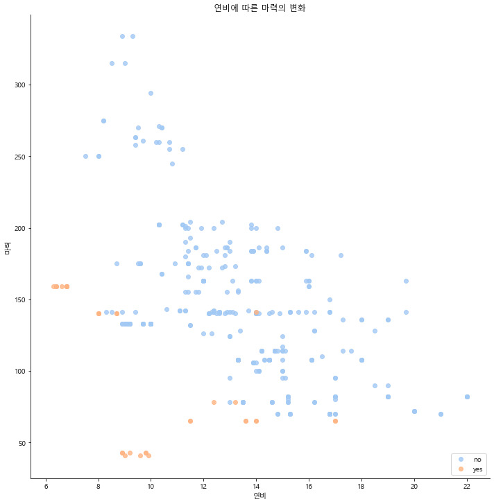

```python
sns.lmplot(size=10, x="연비", y="마력", data=df, fit_reg=False, hue='LPG', legend=False)
plt.legend(loc='lower right')
plt.gca().set_title("연비에 따른 마력의 변화")
```

해당 상관 분석을 통하여 알 수 있는 것은 마력이 감소할수록 연비가 증가하는 경향을 보인다는 것이다. 또한 LPG 차가 그렇지 않는 차에 비해 마력과 연비가 모두 낮은 편이다. 따라서 LPG가 아닌 차를 구매하는 것이 좋을 것으로 판단된다

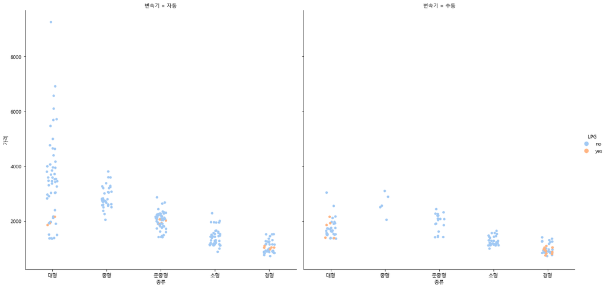

```python
sns.catplot(x='종류', y='가격', data=df, height=8, hue='LPG', col='변속기')
```

좀 더 상세한 분석을 한 결과 차가 작아질 수록 가격이 낮은 것을 알 수 있고, LPG인 차가 더 가격이 낮은 경향을 보이는 것을 알 수 있다. 그리고 변속기가 자동인 차가 수동인 차에 비해 가격이 높은 것을 알 수 있다.  
만약 효율적인 소비를 원한다면 수동 변속기의 가벼운 차를 선호할 것으로 보인다.

**범주형 분석**

연속형끼리의 데이터 분석으로 얻은 결과를 바탕으로 좀 더 자세한 분석을 실시한다  
이를 위해 **가격을 범주로 묶어 범주형 데이터 분석을 실시힌다.**

```python
df.가격.describe()
```

```
count     350.000000
mean     1940.428571
std      1090.465267
min       714.000000
25%      1175.000000
50%      1626.500000
75%      2269.250000
max      9254.000000
Name: 가격, dtype: float64
```

**describe()를 통하여 분석한 결과, 그룹을 min-25%, 25%-50%, 50%-75%, 75%-max로 4개의 범주로 구분한다**

```python
bins = [700, 1175, 1626.5, 2269.25, 9254]

df_pay = pd.cut(df['가격'], bins, labels=['저가', '중저가', '고가', '최고가'])
df['가격그룹'] = df_pay
```

```python
df
```

|  | 가격 | 회사명 | 년식 | 종류 | 연비 | 마력 | 토크 | 연료 | LPG | 하이브리드 | 배기량 | 중량 | 변속기 | 가격그룹 |
| --- | --- | --- | --- | --- | --- | --- | --- | --- | --- | --- | --- | --- | --- | --- |
| 5 | 5680 | 기아 | 2015 | 대형 | 9.3 | 334.0 | 40.3 | 가솔린 | no | no | 3778.0 | 1940.0 | 자동 | 최고가 |
| 6 | 6910 | 현대 | 2015 | 대형 | 8.9 | 334.0 | 40.3 | 가솔린 | no | no | 3778.0 | 1915.0 | 자동 | 최고가 |
| 7 | 5463 | 현대 | 2015 | 대형 | 9.0 | 315.0 | 40.5 | 가솔린 | no | no | 3778.0 | 1930.0 | 자동 | 최고가 |
| 8 | 5710 | 현대 | 2015 | 대형 | 8.5 | 315.0 | 40.5 | 가솔린 | no | no | 3778.0 | 2000.0 | 자동 | 최고가 |
| 9 | 9254 | 쌍용 | 2015 | 대형 | 8.0 | 250.0 | 35.0 | 가솔린 | no | no | 3598.0 | 2070.0 | 자동 | 최고가 |
| ... | ... | ... | ... | ... | ... | ... | ... | ... | ... | ... | ... | ... | ... | ... |
| 404 | 741 | 대우 | 2012 | 경형 | 9.8 | 43.0 | 6.7 | LPG | yes | no | 796.0 | 735.0 | 수동 | 저가 |
| 405 | 958 | 대우 | 2015 | 경형 | 9.2 | 43.0 | 6.7 | LPG | yes | no | 796.0 | 865.0 | 수동 | 저가 |
| 406 | 964 | 대우 | 2015 | 경형 | 9.0 | 41.0 | 6.7 | LPG | yes | no | 796.0 | 905.0 | 수동 | 저가 |
| 407 | 904 | 대우 | 2013 | 경형 | 9.9 | 41.0 | 6.7 | LPG | yes | no | 796.0 | 865.0 | 수동 | 저가 |
| 408 | 910 | 대우 | 2013 | 경형 | 9.6 | 41.0 | 6.7 | LPG | yes | no | 796.0 | 905.0 | 수동 | 저가 |

350 rows × 14 columns

가격그룹과 종류를 그룹으로 묶은 후 기초 분석을 실시한다

```python
check = df.groupby(['가격그룹', '종류'])
check.변속기.value_counts().unstack()
```

| 가격그룹 | 변속기 종류 | 수동 | 자동 |
| --- | --- | --- | --- |
| 저가 | 경형 | 32.0 | 28.0 |
|  | 소형 | 14.0 | 15.0 |
| 중저가 | 경형 | 7.0 | 10.0 |
|  | 대형 | 15.0 | 6.0 |
|  | 소형 | 16.0 | 20.0 |
|  | 준중형 | 5.0 | 7.0 |
| 고가 | 대형 | 16.0 | 9.0 |
|  | 소형 | 1.0 | 7.0 |
|  | 준중형 | 12.0 | 39.0 |
|  | 중형 | 1.0 | 2.0 |
| 최고가 | 대형 | 2.0 | 39.0 |
|  | 소형 | NaN | 1.0 |
|  | 준중형 | 2.0 | 8.0 |
|  | 중형 | 4.0 | 32.0 |

```python
check.변속기.value_counts(normalize=True, sort=False).unstack()
```

| 가격그룹 | 변속기 종류 | 수동 | 자동 |
| --- | --- | --- | --- |
| 저가 | 경형 | 0.533333 | 0.466667 |
|  | 소형 | 0.482759 | 0.517241 |
| 중저가 | 경형 | 0.411765 | 0.588235 |
|  | 대형 | 0.714286 | 0.285714 |
|  | 소형 | 0.444444 | 0.555556 |
|  | 준중형 | 0.416667 | 0.583333 |
| 고가 | 대형 | 0.640000 | 0.360000 |
|  | 소형 | 0.125000 | 0.875000 |
|  | 준중형 | 0.235294 | 0.764706 |
|  | 중형 | 0.333333 | 0.666667 |
| 최고가 | 대형 | 0.048780 | 0.951220 |
|  | 소형 | NaN | 1.000000 |
|  | 준중형 | 0.200000 | 0.800000 |
|  | 중형 | 0.111111 | 0.888889 |

groupby 후 해당 분석을 보면 저가 일수록 수동과 자동 변속기의 비율이 비슷한 것을 보이지만, 최고가로 갈수록 자동 변속기의 비율이 높은 것을 보인다

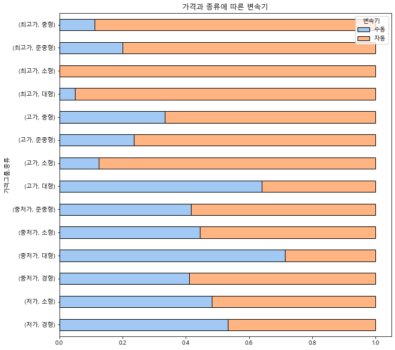

```python
test = check.변속기.value_counts(normalize=True, sort=False)

plt.rcParams["figure.figsize"] = (10,10)
test.unstack().plot(kind='barh', stacked=True, edgecolor='black', width=0.5)
plt.gca().set_title("가격과 종류에 따른 변속기")
```

normalize를 주어 빈도를 비교해본 결과이다. 해당 표를 보면 저가, 대형차 일수록 수동 변속기가 많으며, 최고가 소형일수록 자동변속기가 많은 경향을 보이는 것을 쉽게 알 수 있다

```python
pivot = pd.pivot_table(df, index='가격그룹', columns='종류', values='변속기', aggfunc='count', margins=True)
```

```python
pivot = pivot.drop(['All'], axis=1)
pivot
```

| 종류 가격그룹 | 경형 | 대형 | 소형 | 준중형 | 중형 |
| --- | --- | --- | --- | --- | --- |
| 저가 | 60.0 | NaN | 29.0 | NaN | NaN |
| 중저가 | 17.0 | 21.0 | 36.0 | 12.0 | NaN |
| 고가 | NaN | 25.0 | 8.0 | 51.0 | 3.0 |
| 최고가 | NaN | 41.0 | 1.0 | 10.0 | 36.0 |
| All | 77.0 | 87.0 | 74.0 | 73.0 | 39.0 |

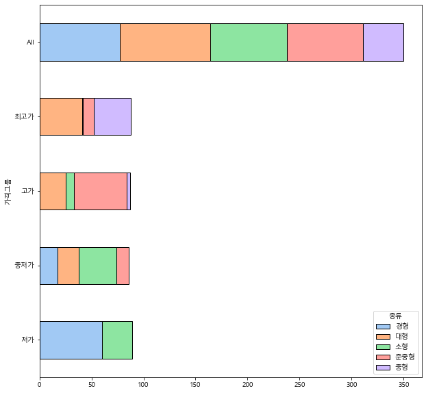

```python
pivot.plot(kind='barh', stacked=True, edgecolor='black')
```

전체적인 수를 비교해 보며, 가격 그룹에 대해 어떤 차 종의 경향을 보이는지 그래프로 나타내었다

**의사결정 결론**

최종 분석 결과는 다음과 같다. 해당 데이터 분석에서 본 결과 연비가 높을 수록 마력이 낮아지는 경향이 있다. 그리고, LPG 가스를 사용을 하면 연비와 마력이 모두 낮아지는 경향을 보인다. 또한, 변속기가 수동인 경우 자동인 경우에 비해 가격이 낮아지는 경향을 보인다. 따라서 효율적인 소비를 원한다면 LPG 가스를 사용하지 않는 변속기가 수동인 차가 좋을 것이다.  
또한, 변속기는 최고가 소형차일수록 없으며, 저가 대형차일수록 수동인 변속기인것을 보인다.  
해당 분석의 최종 결론으로 자동차를 구입할때, 이러한 점을 잘 분석하여 구매를 해야하며, 무작정 연비좋거나, 마력이 좋은 차가 아니라 타협점을 찾아 구매를 해야할 것이다.

**차별화 포인트**

본 데이터 분석을 하면서 차별화된 분석 포인트는 다음과 같다

- 결측값 처리보다 이상치 처리를 먼저 실시하여, 데이터에 대한 신뢰를 높임
- 범주형의 이상치를 제거하기 위해 crosstab()을 이용하여 어떤 group이 있는지 눈으로 확인
- 데이터 분석 과정의 변주형 변수와 연속형 변수의 구분을 명확히 하기 위해 범주형 변수는 object type으로, 연속형 변수는 int, float로 통일
- 의미가 불분명한 데이터를 의미가 분명하도록 치환
- 두 연속형 변수의 상관 관계 분석을 위해 corr() 메소드를 이용
- 연속형 변수를 범주로 묶어 범주형 데이터 분석을 실시
- 범주를 구분하기 위하여 describe()의 결과를 사용 </font>